# Clase 2: Introducción al modelo OLS

# 12 Visualizar los cuatro modelos

Una imagen vale más que una tabla. Este gráfico muestra los cuatro ajustes sobre los datos:

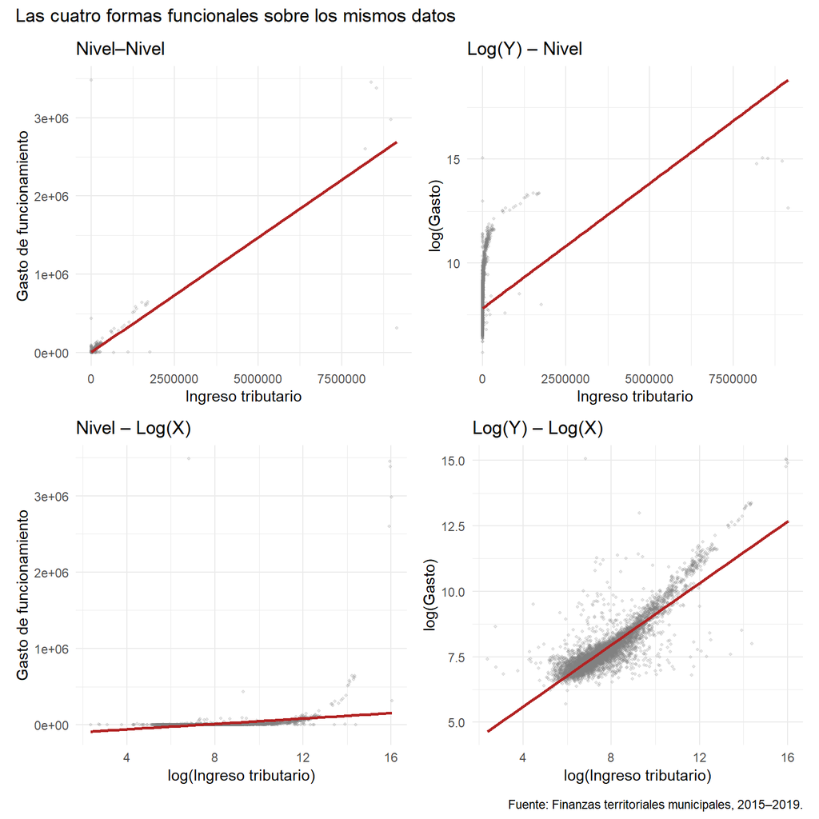

```r
p_nn <- ggplot(fin_limpio, aes(x = INGRESO_TRIBUTARIO, y = GASTO_FUNCIONAMIENTO)) +
  geom_point(alpha = 0.2, color = "grey50", size = 0.8) +
  geom_smooth(method = "lm", color = "firebrick", se = FALSE) +
  labs(title = "Nivel–Nivel",
       x = "Ingreso tributario", y = "Gasto de funcionamiento") +
  theme_minimal()

p_ln <- ggplot(fin_limpio, aes(x = INGRESO_TRIBUTARIO, y = log_gasto)) +
  geom_point(alpha = 0.2, color = "grey50", size = 0.8) +
  geom_smooth(method = "lm", color = "firebrick", se = FALSE) +
  labs(title = "Log(Y) – Nivel",
       x = "Ingreso tributario", y = "log(Gasto)") +
  theme_minimal()

p_nl <- ggplot(fin_limpio, aes(x = log_ing, y = GASTO_FUNCIONAMIENTO)) +
  geom_point(alpha = 0.2, color = "grey50", size = 0.8) +
  geom_smooth(method = "lm", color = "firebrick", se = FALSE) +
  labs(title = "Nivel – Log(X)",
       x = "log(Ingreso tributario)", y = "Gasto de funcionamiento") +
  theme_minimal()

p_ll <- ggplot(fin_limpio, aes(x = log_ing, y = log_gasto)) +
  geom_point(alpha = 0.2, color = "grey50", size = 0.8) +
  geom_smooth(method = "lm", color = "firebrick", se = FALSE) +
  labs(title = "Log(Y) – Log(X)",
       x = "log(Ingreso tributario)", y = "log(Gasto)") +
  theme_minimal()

library(patchwork)
(p_nn | p_ln) / (p_nl | p_ll) +
  plot_annotation(
    title   = "Las cuatro formas funcionales sobre los mismos datos",
    caption = "Fuente: Finanzas territoriales municipales, 2015–2019."
  )
```

# 13 Tabla resumen de interpretaciones

[output not shown]

> Los valores exactos salen de sus propias estimaciones. La tabla es para que recuerden **qué pregunta responde cada especificación**.

# 14 Ejercicio para la sesión

Con la misma base, estimen la siguiente regresión:

$$\ln(\text{Gasto}_i) = \beta_0 + \beta_1
\ln(\text{Transferencias SGP}_i) + \varepsilon_i$$

1. Creen las variables en logaritmo (filtren primero para quedarse solo con observaciones con transferencias positivas).
2. Hagan el scatter (en escala log) antes de estimar.
3. Estimen el modelo con `lm()` y usen `tidy()` para ver los coeficientes.
4. **Interpreten** $\hat\beta_1$: ¿qué le pasa al gasto si las transferencias del SGP aumentan 1%?
5. Reporten el $R^2$ y compárenlo con el modelo de ingreso tributario log–log. ¿Cuál variable “explica mejor” el gasto?

```r
# Espacio para trabajar en clase
fin_ej <- fin_limpio |>
  filter(TRANSFERENCIAS_SGP > 0) |>
  mutate(log_sgp = log(TRANSFERENCIAS_SGP))

# 1. Scatter



# 2. Regresión



# 3. Interpretación del coeficiente



# 4. R2
```

*Clase preparada para Econometría 1 — ECON 3311 / ECON 3321 | Universidad de los Andes | 2026-19*